# Statistical analysis and visualization of functional profiles for gene and gene clusters

Guangchuang Yu (guangchuangyu@gmail.com) School of Public Health, The University of Hong Kong

2015-08-26

# 1 Abstract

*[clusterProfiler](http://bioconductor.org/packages/release/bioc/html/clusterProfiler.html)* supports enrichment analysis of Gene Ontology (GO) and Kyoto Encyclopedia of genes and Genomes (KEGG) with either hypergeometric test or Gene Set Enrichment Analysis (GSEA). *[clusterProfiler](http://bioconductor.org/packages/release/bioc/html/clusterProfiler.html)* adjust the estimated significance level to account for multiple hypothesis testing and also *q-values* were calculated for FDR control. It supports several visualization methods, including `barplot`, `cnetplot`, `enrichMap` and `gseaplot`. *[clusterProfiler](http://bioconductor.org/packages/release/bioc/html/clusterProfiler.html)* also supports comparing functional profiles among gene clusters. It supports comparing biological themes of GO, KEGG, Disease Ontology (via *[DOSE](http://bioconductor.org/packages/release/bioc/html/DOSE.html)*) and Reactome pathways (via *[ReactomePA](http://bioconductor.org/packages/release/bioc/html/ReactomePA.html)*).

# 2 Citation

If you use *[clusterProfiler](http://bioconductor.org/packages/release/bioc/html/clusterProfiler.html)* in published research, please cite:

```
G Yu, LG Wang, Y Han, QY He.
clusterProfiler: an R package for comparing biological themes among gene clusters.
OMICS: A Journal of Integrative Biology 2012, 16(5):284-287.
```

URL: http://dx.doi.org/10.1089/omi.2011.0118

# 3 Introduction

In recently years, high-throughput experimental techniques such as microarray, RNA-Seq and mass spectrometry can detect cellular molecules at systems-level. These kinds of analyses generate huge quantitaties of data, which need to be given a biological interpretation. A commonly used approach is via clustering in the gene dimension for grouping different genes based on their similarities<sup>1</sup>.

To search for shared functions among genes, a common way is to incorporate the biological knowledge, such as Gene Ontology (GO) and Kyoto Encyclopedia of Genes and Genomes (KEGG), for identifying predominant biological themes of a collection of genes.

After clustering analysis, researchers not only want to determine whether there is a common theme of a particular gene cluster, but also to compare the biological themes among gene clusters. The manual step to choose interesting clusters followed by enrichment analysis on each selected cluster is slow and tedious. To bridge this gap, we designed *[clusterProfiler](http://bioconductor.org/packages/release/bioc/html/clusterProfiler.html)*<sup>2</sup>, for comparing and visualizing functional profiles among gene clusters.

# 4 bitr: Biological Id TranslatoR

Many new R user may find traslating ID is a tedious task and I have received many feedbacks from *[clusterProfiler](http://bioconductor.org/packages/release/bioc/html/clusterProfiler.html)* users that they don’t know how to convert gene symbol, uniprot ID or other ID types to Entrez gene ID that used in *[clusterProfiler](http://bioconductor.org/packages/release/bioc/html/clusterProfiler.html)* for most of the species.

To remove this obstacle, We provide `bitr` function for translating among different gene ID types.

```r
x <- c("GPX3",  "GLRX",   "LBP",   "CRYAB", "DEFB1", "HCLS1",   "SOD2",   "HSPA2",
       "ORM1",  "IGFBP1", "PTHLH", "GPC3",  "IGFBP3","TOB1",    "MITF",   "NDRG1",
       "NR1H4", "FGFR3",  "PVR",   "IL6",   "PTPRM", "ERBB2",   "NID2",   "LAMB1",
       "COMP",  "PLS3",   "MCAM",  "SPP1",  "LAMC1", "COL4A2",  "COL4A1", "MYOC",
       "ANXA4", "TFPI2",  "CST6",  "SLPI",  "TIMP2", "CPM",     "GGT1",   "NNMT",
       "MAL",   "EEF1A2", "HGD",   "TCN2",  "CDA",   "PCCA",    "CRYM",   "PDXK",
       "STC1",  "WARS",  "HMOX1", "FXYD2", "RBP4",   "SLC6A12", "KDELR3", "ITM2B")
eg = bitr(x, fromType="SYMBOL", toType="ENTREZID", annoDb="org.Hs.eg.db")
head(eg)
```

```
##   SYMBOL ENTREZID
## 1   GPX3     2878
## 2   GLRX     2745
## 3    LBP     3929
## 4  CRYAB     1410
## 5  DEFB1     1672
## 6  HCLS1     3059
```

User should provides an annotation package, both *fromType* and *toType* can accept any types that supported.

User can use *idType* to list all supporting types.

```r
idType("org.Hs.eg.db")
```

```
##  [1] "ACCNUM"       "ALIAS"        "ENSEMBL"      "ENSEMBLPROT"
##  [5] "ENSEMBLTRANS" "ENTREZID"     "ENZYME"       "EVIDENCE"
##  [9] "EVIDENCEALL"  "GENENAME"     "GO"           "GOALL"
## [13] "IPI"          "MAP"          "OMIM"         "ONTOLOGY"
## [17] "ONTOLOGYALL"  "PATH"         "PFAM"         "PMID"
## [21] "PROSITE"      "REFSEQ"       "SYMBOL"       "UCSCKG"
## [25] "UNIGENE"      "UNIPROT"
```

We can translate from one type to other types.

```r
ids <- bitr(x, fromType="SYMBOL", toType=c("UNIPROT", "ENSEMBL"), annoDb="org.Hs.eg.db")
head(ids)
```

```
##   SYMBOL    UNIPROT         ENSEMBL
## 1   GPX3     P22352 ENSG00000211445
## 2   GLRX A0A024RAM2 ENSG00000173221
## 3   GLRX     P35754 ENSG00000173221
## 4    LBP     P18428 ENSG00000129988
## 5    LBP     Q8TCF0 ENSG00000129988
## 6  CRYAB     P02511 ENSG00000109846
```

# 5 Gene Ontology analysis

## 5.1 Supported organisms

At present, GO analysis in *[clusterProfiler](http://bioconductor.org/packages/release/bioc/html/clusterProfiler.html)* supports about 20 species internally as shown below:

- Arabidopsis
- Anopheles
- Bovine
- Canine
- Chicken
- Chimp
- Coelicolor
- E coli strain K12
- E coli strain Sakai
- Fly
- Gondii
- Human
- Malaria
- Mouse
- Pig
- Rat
- Rhesus
- Worm
- Xenopus
- Yeast
- Zebrafish

For un-supported organisms, user can use their own GO annotation data (in data.frame format with first column of gene ID and second column of GO ID) and passed it to `enricher` function (see Universal enrichment analysis section).

If a gene is annotated by a GO ID (direction annotation), it should also annotated by its ancestor GO nodes (indirect annation). If user only has direct annotation, they can pass their annotation to `buildGOmap` function, which will infer indirection annotation and generate annotation file that suitable for `enrichGO` function. In future version, we may add functions to help user query annotation from public available database.

## 5.2 Gene Ontology Classification

In *[clusterProfiler](http://bioconductor.org/packages/release/bioc/html/clusterProfiler.html)*, `groupGO` is designed for gene classification based on GO distribution at a specific level. Here we use dataset *geneList* provided by *[DOSE](http://bioconductor.org/packages/release/bioc/html/DOSE.html)*. Please refer to vignette of *[DOSE](http://bioconductor.org/packages/release/bioc/html/DOSE.html)* for more details.

```r
library("DOSE")
data(geneList)
gene <- names(geneList)[abs(geneList) > 2]
head(gene)
```

```
## [1] "4312"  "8318"  "10874" "55143" "55388" "991"
```

```r
ggo <- groupGO(gene     = gene,
               organism = "human",
               ont      = "BP",
               level    = 3,
               readable = TRUE)
head(summary(ggo))
```

[output not shown]

The input parameters of *gene* is a vector of gene IDs. It expects entrezgene for most of the organisms. For yeast, it should be ORF IDs; *organism* should be the common name of supported species. If *readable* is setting to *TRUE*, the input gene IDs will be converted to gene symbols.

## 5.3 GO over-representation test

Over-representation test<sup>3</sup> were implemented in *[clusterProfiler](http://bioconductor.org/packages/release/bioc/html/clusterProfiler.html)*. For calculation details, please refer to the vignette of *[DOSE](http://bioconductor.org/packages/release/bioc/html/DOSE.html)*.

```r
ego <- enrichGO(gene          = gene,
                universe      = names(geneList),
                organism      = "human",
                ont           = "CC",
                pAdjustMethod = "BH",
                pvalueCutoff  = 0.01,
                qvalueCutoff  = 0.05,
                readable      = TRUE)
head(summary(ego))
```

[output not shown]

A detail explanation of the parameter can be found in the vignette of *[DOSE](http://bioconductor.org/packages/release/bioc/html/DOSE.html)*.

## 5.4 GO Gene Set Enrichment Analysis

A common approach in analyzing gene expression profiles was identifying differential expressed genes that are deemed interesting. The enrichment analysis we demonstrated previous were based on these differential expressed genes. This approach will find genes where the difference is large, but it will not detect a situation where the difference is small, but evidenced in coordinated way in a set of related genes. Gene Set Enrichment Analysis (GSEA)<sup>4</sup> directly addresses this limitation. All genes can be used in GSEA; GSEA aggregates the per gene statistics across genes within a gene set, therefore making it possible to detect situations where all genes in a predefined set change in a small but coordinated way. Since it is likely that many relevant phenotypic differences are manifested by small but consistent changes in a set of genes.

For algorithm details, please refer to the vignette of *[DOSE](http://bioconductor.org/packages/release/bioc/html/DOSE.html)*.

```r
ego2 <- gseGO(geneList     = geneList,
              organism     = "human",
              ont          = "CC",
              nPerm        = 1000,
              minGSSize    = 120,
              pvalueCutoff = 0.01,
              verbose      = FALSE)
```

GSEA use permutation test, user can set *nPerm* for number of permutations. Gene Set size below *minGSSize* will be omitted.

## 5.5 GO Semantic Similarity Analysis

GO semantic similarity can be calculated by *[GOSemSim](http://bioconductor.org/packages/release/bioc/html/GOSemSim.html)*<sup>1</sup>. We can use it to cluster genes/proteins into different clusters based on their functional similarity and can also use it to measure the similarities among GO terms to reduce the redundancy of GO enrichment results.

# 6 KEGG analysis

The annotation package, *[KEGG.db](http://bioconductor.org/packages/release/data/annotation/html/KEGG.db.html)*, is not updated since 2012. It’s now pretty old and in *[clusterProfiler](http://bioconductor.org/packages/release/bioc/html/clusterProfiler.html)*, `enrichKEGG` supports downloading latest online version of KEGG data for enrichment analysis. Using *[KEGG.db](http://bioconductor.org/packages/release/data/annotation/html/KEGG.db.html)* is also supported by explicitly setting *use_internal_data* parameter to *TRUE*, but it’s not recommended.

With this new feature, organism is not restricted to those supported in previous release, it can be any species that have KEGG annotation data available in KEGG database. User should pass abbreviation of academic name to the *organism* parameter. The full list of KEGG supported organisms can be accessed via http://www.genome.jp/kegg/catalog/org_list.html.

## 6.1 KEGG over-representation test

To speed up the compilation of this document, we set `use_internal_data = TRUE`.

```r
kk <- enrichKEGG(gene         = gene,
                 organism     = "human",
                 pvalueCutoff = 0.05,
                 readable     = TRUE,
                 use_internal_data = TRUE)
head(summary(kk))
```

```
##                ID                             Description GeneRatio
## hsa04110 hsa04110                              Cell cycle     11/74
## hsa04114 hsa04114                          Oocyte meiosis     10/74
## hsa03320 hsa03320                  PPAR signaling pathway      7/74
## hsa04914 hsa04914 Progesterone-mediated oocyte maturation      6/74
## hsa04115 hsa04115                   p53 signaling pathway      5/74
## hsa04062 hsa04062             Chemokine signaling pathway      8/74
##           BgRatio       pvalue     p.adjust       qvalue
## hsa04110 128/5894 4.309086e-07 4.826176e-05 4.762674e-05
## hsa04114 114/5894 1.252655e-06 7.014870e-05 6.922569e-05
## hsa03320  70/5894 2.351387e-05 8.778511e-04 8.663005e-04
## hsa04914  87/5894 7.212570e-04 2.019520e-02 1.992947e-02
## hsa04115  69/5894 1.637682e-03 3.668408e-02 3.620140e-02
## hsa04062 189/5894 2.373246e-03 4.430059e-02 4.371768e-02
##                                                                  geneID
## hsa04110 CDC45/CDC20/CCNB2/CCNA2/CDK1/MAD2L1/TTK/CHEK1/CCNB1/MCM5/PTTG1
## hsa04114     CDC20/CCNB2/CDK1/MAD2L1/CALML5/AURKA/CCNB1/PTTG1/ITPR1/PGR
## hsa03320                      MMP1/FADS2/ADIPOQ/PCK1/FABP4/HMGCS2/PLIN1
## hsa04914                              CCNB2/CCNA2/CDK1/MAD2L1/CCNB1/PGR
## hsa04115                                    CCNB2/RRM2/CDK1/CHEK1/CCNB1
## hsa04062            CXCL10/CXCL13/CXCL11/CXCL9/CCL18/CCL8/CXCL14/CX3CR1
##          Count
## hsa04110    11
## hsa04114    10
## hsa03320     7
## hsa04914     6
## hsa04115     5
## hsa04062     8
```

## 6.2 KEGG Gene Set Enrichment Analysis

```r
kk2 <- gseKEGG(geneList     = geneList,
               organism     = "human",
               nPerm        = 1000,
               minGSSize    = 120,
               pvalueCutoff = 0.01,
               verbose      = FALSE,
               use_internal_data = TRUE)
head(summary(kk2))
```

```
##                ID                            Description setSize
## hsa01100 hsa01100                     Metabolic pathways     920
## hsa04062 hsa04062            Chemokine signaling pathway     166
## hsa04510 hsa04510                         Focal adhesion     193
## hsa03013 hsa03013                          RNA transport     124
## hsa04060 hsa04060 Cytokine-cytokine receptor interaction     233
##          enrichmentScore      pvalue    p.adjust     qvalues
## hsa01100       0.2360780 0.000999001 0.004195804 0.002944424
## hsa04062       0.3831672 0.000999001 0.004195804 0.002944424
## hsa04510      -0.4463585 0.000999001 0.004195804 0.002944424
## hsa03013       0.4271821 0.000999001 0.004195804 0.002944424
## hsa04060       0.3394553 0.000999001 0.004195804 0.002944424
```

# 7 Disease Ontology analysis

*[DOSE](http://bioconductor.org/packages/release/bioc/html/DOSE.html)*<sup>5</sup> supports Disease Ontology (DO) Semantic and Enrichment analysis, please refer to the package vignettes. The `enrichDO` function is very useful for identifying disease association of interesting genes, and function `gseAnalyzer` function is designed for gene set enrichment analysis of *DO*.

# 8 Reactome pathway analysis

*[ReactomePA](http://bioconductor.org/packages/release/bioc/html/ReactomePA.html)* uses Reactome as a source of pathway data. The function call of `enrichPathway` and `gsePathway` in *[ReactomePA](http://bioconductor.org/packages/release/bioc/html/ReactomePA.html)* is consistent with `enrichKEGG` and `gseKEGG`.

# 9 DAVID functional analysis

```r
david <- enrichDAVID(gene = gene,
                     idType = "ENTREZ_GENE_ID",
                     listType = "Gene",
                     annotation = "KEGG_PATHWAY",
                     david.user = "clusterProfiler@hku.hk")
```

DAVID Web Service has the following limitations:

- A job with more than 3000 genes to generate gene or term cluster report will not be handled by DAVID due to resource limit.
- No more than 200 jobs in a day from one user or computer.
- DAVID Team reserves right to suspend any improper uses of the web service without notice.

For more details, please refer to http://david.abcc.ncifcrf.gov/content.jsp?file=WS.html.

As user has limited usage, please [register](http://david.abcc.ncifcrf.gov/webservice/register.htm) and use your own user account to run *enrichDAVID*.

# 10 Universal enrichment analysis

*[clusterProfiler](http://bioconductor.org/packages/release/bioc/html/clusterProfiler.html)* supports both hypergeometric test and gene set enrichment analysis of many ontology/pathway, but it’s still not enough for users may want to analyze their data with unsupported organisms, slim version of GO, novel functional annotation (e.g. GO via BlastGO or KEGG via KAAS), unsupported ontologies/pathways or customized annotations.

*[clusterProfiler](http://bioconductor.org/packages/release/bioc/html/clusterProfiler.html)* provides `enricher` function for hypergeometric test and `GSEA` function for gene set enrichment analysis that are designed to accept user defined annotation. They accept two additional parameters *TERM2GENE* and *TERM2NAME*. As indicated in the parameter names, *TERM2GENE* is a data.frame with first column of term ID and second column of corresponding mapped gene and *TERM2NAME* is a data.frame with first column of term ID and second column of corresponding term name. *TERM2NAME* is optional.

An example of using `enricher` and `GSEA` to analyze [DisGeNet](http://www.disgenet.org/web/DisGeNET/menu/home) annotation is presented in [use clusterProfiler as an universal enrichment analysis tool](http://ygc.name/2015/05/11/use-clusterprofiler-as-an-universal-enrichment-analysis-tool/).

# 11 Functional analysis of NGS data

Functional analysis using NGS data (eg, RNA-Seq and ChIP-Seq) can be performed by linking coding and non-coding regions to coding genes via *[ChIPseeker](http://bioconductor.org/packages/release/bioc/html/ChIPseeker.html)*<sup>8</sup> package, which can annotates genomic regions to their nearest genes, host genes, and flanking genes respectivly. In addtion, it provides a function, *seq2gene*, that simultaneously considering host genes, promoter region and flanking gene from intergenic region that may under control via cis-regulation. This function maps genomic regions to genes in a many-to-many manner and facilitate functional analysis. For more details, please refer to *[ChIPseeker](http://bioconductor.org/packages/release/bioc/html/ChIPseeker.html)*.

# 12 Visualization

The function calls of `groupGO`, `enrichGO`, `enrichKEGG`, `enrichDO` and `enrichPathway` are consistent and all the output can be visualized by bar plot, enrichment map and category-gene-network plot. It is very common to visualize the enrichment result in bar or pie chart. We believe the pie chart is misleading and only provide bar chart.

## 12.1 barplot

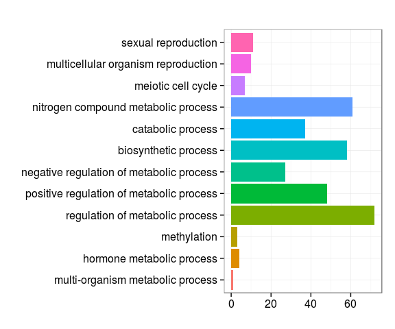

```r
barplot(ggo, drop=TRUE, showCategory=12)
```

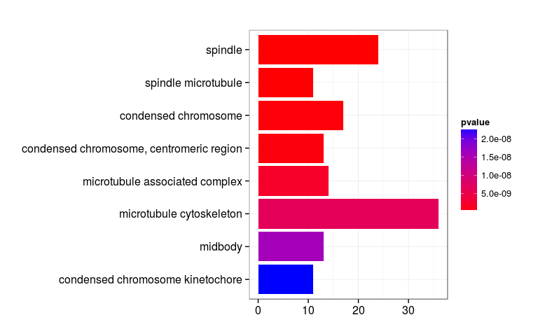

```r
barplot(ego, showCategory=8)
```

## 12.2 dotplot

[*dotplot*](http://ygc.name/2015/06/23/dotplot-for-enrichment-result/) is a good alternative to *barplot*.

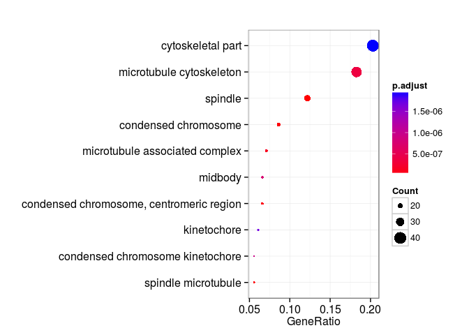

```r
dotplot(ego)
```

## 12.3 enrichMap

Enrichment map can be viusalized by `enrichMap`, which also support results obtained from hypergeometric test and gene set enrichment analysis.

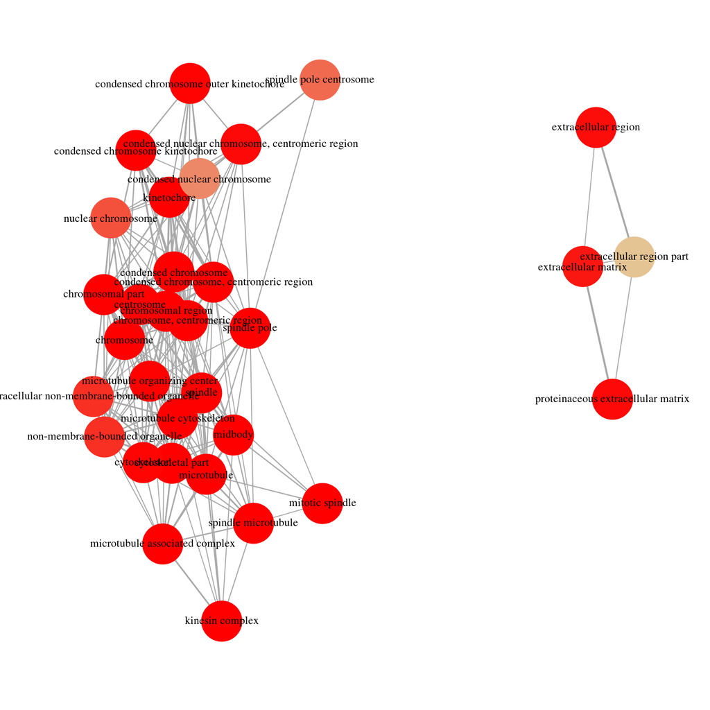

```r
enrichMap(ego)
```

## 12.4 cnetplot

In order to consider the potentially biological complexities in which a gene may belong to multiple annotation categories and provide information of numeric changes if available, we developed `cnetplot` function to extract the complex association.

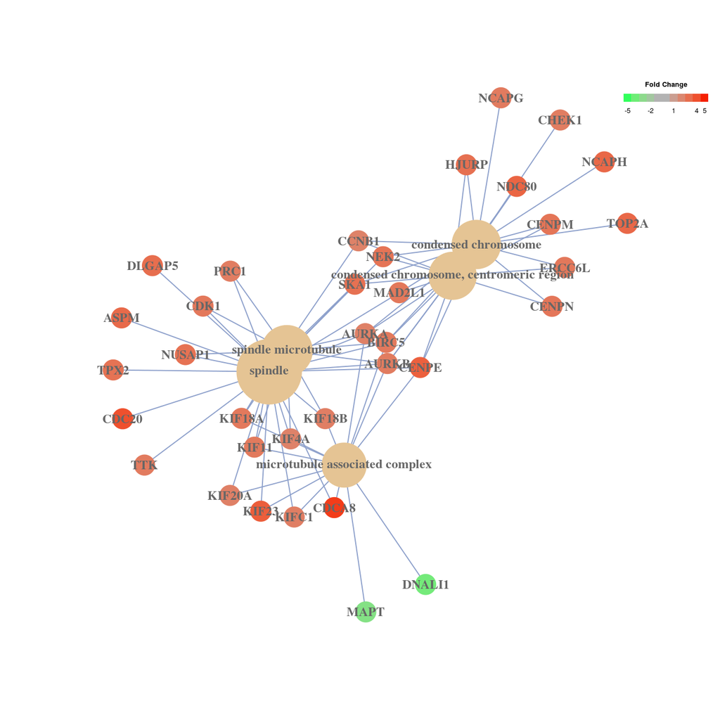

```r
cnetplot(ego, categorySize="pvalue", foldChange=geneList)
```

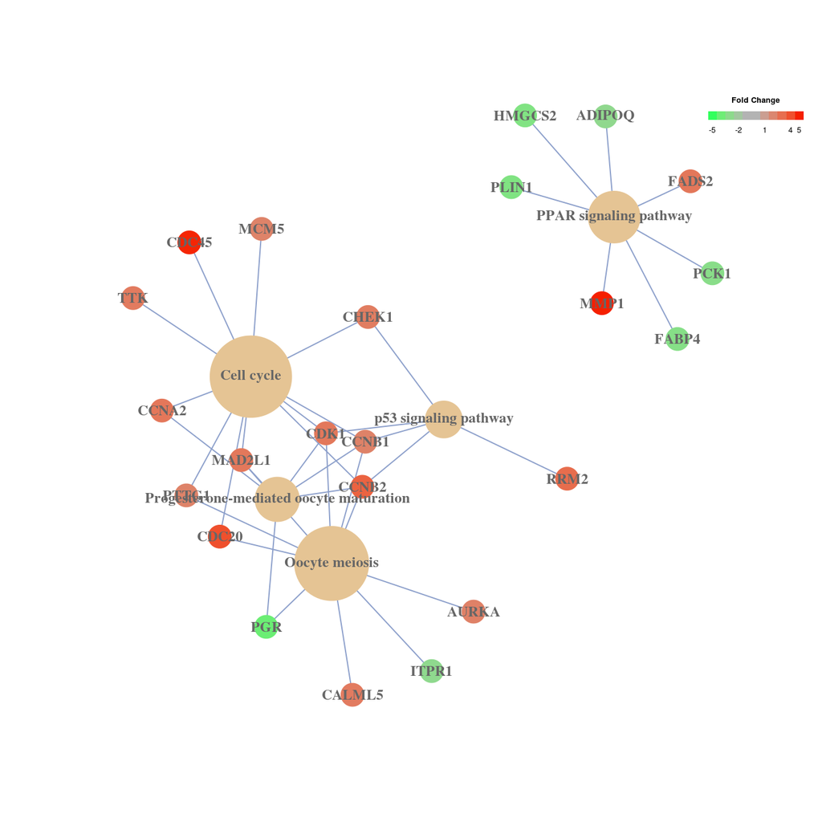

```r
cnetplot(kk, categorySize="geneNum", foldChange=geneList)
```

## 12.5 gseaplot

Running score of gene set enrichment analysis and its association of phenotype can be visualized by `gseaplot`.

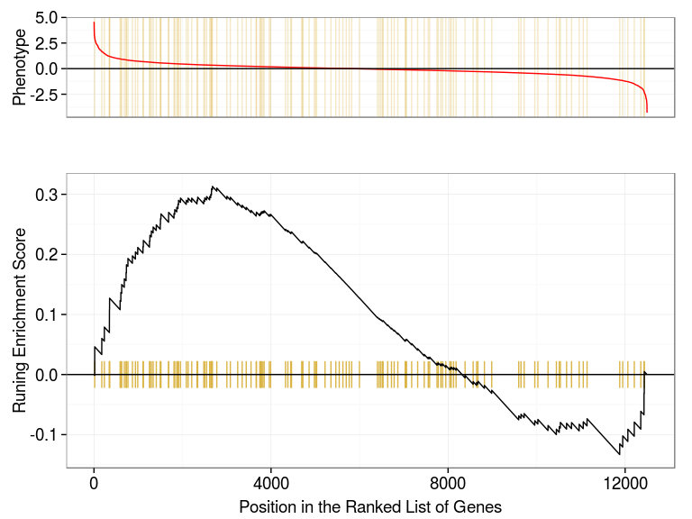

```r
gseaplot(kk2, geneSetID = "hsa04145")
```

## 12.6 plotGOgraph

`plotGOgraph`, which is based on *[topGO](http://bioconductor.org/packages/release/bioc/html/topGO.html)*, can accept output of `enrichGO` and visualized the enriched GO induced graph.

```
##
## groupGOTerms:    GOBPTerm, GOMFTerm, GOCCTerm environments built.
##
## Building most specific GOs ..... ( 332 GO terms found. )
##
## Build GO DAG topology .......... ( 332 GO terms and 663 relations. )
##
## Annotating nodes ............... ( 11609 genes annotated to the GO terms. )
```

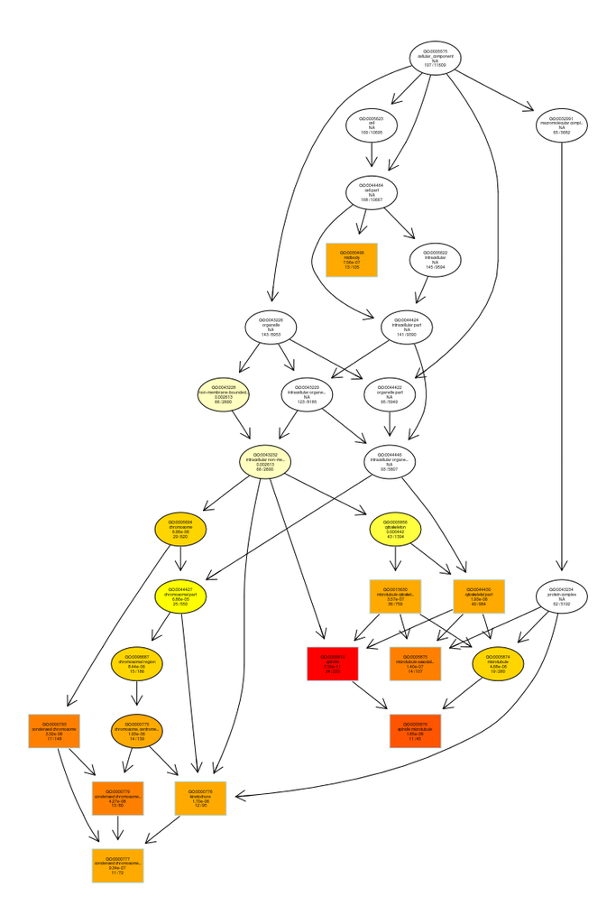

```
## $dag
## A graphNEL graph with directed edges
## Number of Nodes = 29
## Number of Edges = 50
##
## $complete.dag
## [1] "A graph with 29 nodes."
```

```r
plotGOgraph(ego)
```

## 12.7 pathview from pathview package

*[clusterProfiler](http://bioconductor.org/packages/release/bioc/html/clusterProfiler.html)* users can also use `pathview` from the *[pathview](http://bioconductor.org/packages/release/bioc/html/pathview.html)*<sup>9</sup> to visualize KEGG pathway.

The following example illustrate how to visualize “hsa04110” pathway, which was enriched in our previous analysis.

```r
library("pathview")
hsa04110 <- pathview(gene.data  = geneList,
                     pathway.id = "hsa04110",
                     species    = "hsa",
                     limit      = list(gene=max(abs(geneList)), cpd=1))
```

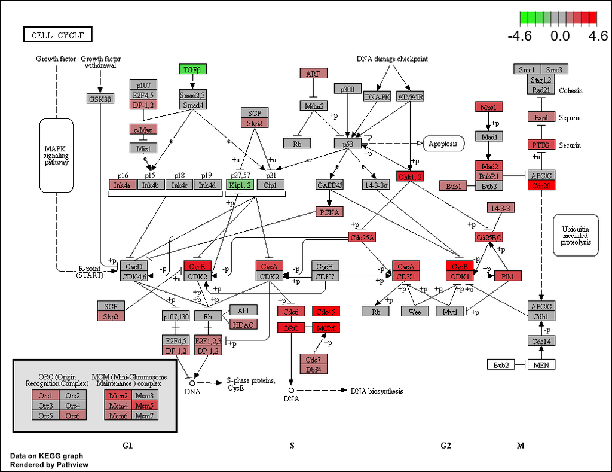

For further information, please refer to the vignette of *[pathview](http://bioconductor.org/packages/release/bioc/html/pathview.html)*<sup>9</sup>.

# 13 Biological theme comparison

*[clusterProfiler](http://bioconductor.org/packages/release/bioc/html/clusterProfiler.html)* was developed for biological theme comparison<sup>2</sup>, and it provides a function, `compareCluster`, to automatically calculate enriched functional categories of each gene clusters.

```r
data(gcSample)
lapply(gcSample, head)
```

```
## $X1
## [1] "4597"  "7111"  "5266"  "2175"  "755"   "23046"
##
## $X2
## [1] "23450" "5160"  "7126"  "26118" "8452"  "3675"
##
## $X3
## [1] "894"   "7057"  "22906" "3339"  "10449" "6566"
##
## $X4
## [1] "5573"  "7453"  "5245"  "23450" "6500"  "4926"
##
## $X5
## [1] "5982" "7318" "6352" "2101" "8882" "7803"
##
## $X6
## [1] "5337"  "9295"  "4035"  "811"   "23365" "4629"
##
## $X7
## [1] "2621" "2665" "5690" "3608" "3550" "533"
##
## $X8
## [1] "2665" "4735" "1327" "3192" "5573" "9528"
```

The input for *geneCluster* parameter should be a named list of gene IDs.

```r
ck <- compareCluster(geneCluster = gcSample, fun = "enrichKEGG")
head(summary(ck))
```

```
##   Cluster       ID                  Description GeneRatio  BgRatio
## 1      X2 hsa04110                   Cell cycle    18/342 124/6948
## 2      X2 hsa05200           Pathways in cancer    36/342 398/6948
## 3      X2 hsa05340     Primary immunodeficiency     8/342  36/6948
## 4      X2 hsa04064 NF-kappa B signaling pathway    13/342  91/6948
## 5      X2 hsa05166             HTLV-I infection    25/342 259/6948
## 6      X3 hsa04512     ECM-receptor interaction     9/163  87/6948
##         pvalue    p.adjust      qvalue
## 1 3.158217e-05 0.007958706 0.007612964
## 2 2.522145e-04 0.023999019 0.022956455
## 3 2.857026e-04 0.023999019 0.022956455
## 4 4.655083e-04 0.029327023 0.028053001
## 5 9.005148e-04 0.045385944 0.043414290
## 6 1.847919e-04 0.040099834 0.036958372
##                                                                                                                                                                         geneID
## 1                                                                                      991/1869/890/1871/701/990/10926/9088/8317/9700/9134/1029/2810/699/11200/23594/8555/4173
## 2 3675/1956/1869/324/3480/1871/113/1902/5613/2261/1909/637/355/5888/9134/5915/3908/2246/5154/7704/4437/1029/185/7187/3551/3479/332/5733/330/6654/1288/5914/405/54583/2122/6772
## 3                                                                                                                                          100/6891/3932/973/916/925/958/64421
## 4                                                                                                              4067/3383/7128/3932/5971/4050/6850/7187/3551/10892/5588/330/958
## 5                                                      3383/991/1869/5424/324/1871/113/701/5613/3932/5971/916/5154/5427/4487/3600/1029/3551/8498/4488/11200/4776/4603/4214/958
## 6                                                                                                                                 7057/3339/3695/1101/3679/3910/3696/1302/3693
##   Count
## 1    18
## 2    36
## 3     8
## 4    13
## 5    25
## 6     9
```

## 13.1 Formula interface of compareCluster

`compareCluster` also supports passing a formula (the code to support formula has been contributed by Giovanni Dall’Olio) of type $Entrez \sim group$ or $Entrez \sim group + othergroup$.

```r
## formula interface
mydf <- data.frame(Entrez=c('1', '100', '1000', '100101467',
                       '100127206', '100128071'),
                   group = c('A', 'A', 'A', 'B', 'B', 'B'),
                   othergroup = c('good', 'good', 'bad', 'bad',
                       'good', 'bad'))
xx.formula <- compareCluster(Entrez~group, data=mydf, fun='groupGO')
head(summary(xx.formula))
```

```
##   Cluster         ID          Description Count GeneRatio     geneID
## 1       A GO:0016020             membrane     2       2/3   100/1000
## 2       A GO:0005576 extracellular region     3       3/3 1/100/1000
## 3       A GO:0005623                 cell     2       2/3   100/1000
## 4       A GO:0009295             nucleoid     0       0/3
## 5       A GO:0019012               virion     0       0/3
## 6       A GO:0030054        cell junction     2       2/3   100/1000
```

```r
## formula interface with more than one grouping variable
xx.formula.twogroups <- compareCluster(Entrez~group+othergroup,
                                       data=mydf, fun='groupGO')
head(summary(xx.formula.twogroups))
```

```
##   Cluster         ID          Description Count GeneRatio geneID
## 1   A.bad GO:0016020             membrane     1       1/1   1000
## 2   A.bad GO:0005576 extracellular region     1       1/1   1000
## 3   A.bad GO:0005623                 cell     1       1/1   1000
## 4   A.bad GO:0009295             nucleoid     0       0/1
## 5   A.bad GO:0019012               virion     0       0/1
## 6   A.bad GO:0030054        cell junction     1       1/1   1000
```

## 13.2 Visualization of profile comparison

We can visualize the result using `plot` method.

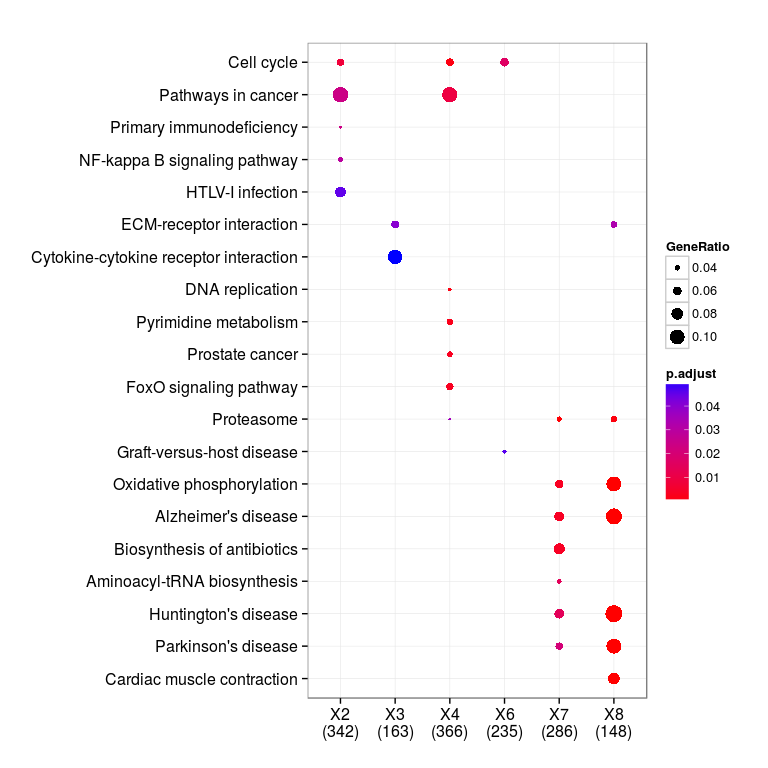

```r
plot(ck)
```

By default, only top 5 (most significant) categories of each cluster was plotted. User can changes the parameter *showCategory* to specify how many categories of each cluster to be plotted, and if *showCategory* was set to *NULL*, the whole result will be plotted.

The *plot* function accepts a parameter *by* for setting the scale of dot sizes. The default parameter *by* is setting to “geneRatio”, which corresponding to the “GeneRatio” column of the output. If it was setting to *count*, the comparison will be based on gene counts, while if setting to *rowPercentage*, the dot sizes will be normalized by *count/(sum of each row)*

To provide the full information, we also provide number of identified genes in each category (numbers in parentheses) when *by* is setting to *rowPercentage* and number of gene clusters in each cluster label (numbers in parentheses) when *by* is setting to *geneRatio*, as shown in Figure 3. If the dot sizes were based on *count*, the row numbers will not shown.

The p-values indicate that which categories are more likely to have biological meanings. The dots in the plot are color-coded based on their corresponding p-values. Color gradient ranging from red to blue correspond to in order of increasing p-values. That is, red indicate low p-values (high enrichment), and blue indicate high p-values (low enrichment). P-values and adjusted p-values were filtered out by the threshold giving by parameter *pvalueCutoff*, and FDR can be estimated by *qvalue*.

User can refer to the example in<sup>2</sup>; we analyzed the publicly available expression dataset of breast tumour tissues from 200 patients (GSE11121, Gene Expression Omnibus)<sup>10</sup>. We identified 8 gene clusters from differentially expressed genes, and using `compareCluster` to compare these gene clusters by their enriched biological process.

Another example was shown in<sup>11</sup>, we calculated functional similarities among viral miRNAs using method described in<sup>12</sup>, and compared significant KEGG pathways regulated by different viruses using `compareCluster`.

The comparison function was designed as a framework for comparing gene clusters of any kind of ontology associations, not only `groupGO`, `enrichGO`, `enrichKEGG` and `enricher` provided in this package, but also other biological and biomedical ontologies, for instance, `enrichDO` from *[DOSE](http://bioconductor.org/packages/release/bioc/html/DOSE.html)*<sup>5</sup> and `enrichPathway` from *[ReactomePA](http://bioconductor.org/packages/release/bioc/html/ReactomePA.html)* work fine with `compareCluster` for comparing biological themes in disease and reactome pathway perspective. More details can be found in the vignettes of *[DOSE](http://bioconductor.org/packages/release/bioc/html/DOSE.html)*<sup>5</sup> and *[ReactomePA](http://bioconductor.org/packages/release/bioc/html/ReactomePA.html)*.